# BIOL-607 Biological Data Analysis Homework 1: Sampling and Simulation

Andrew Judell-Halfpenny

September 21, 2018

GRADED: 29/48 Try to read the questions more carefully next time Andrew! Also, if you are going to output to a pdf, limit how many results print out by putting echo=FALSE in the title of the chunk

# 1. R Warmup

## 1a. Create a vector of 100 randomly distributed numbers between 0 and 100 using runif and save the vector into the variable my_vec. If you cannot figure out runif, try ?runif. What information does str and summary tell you about my_vec? How do they differ?

You should put a title on each of your chunks. Name them something unique and related to the question, or at least name them “1a” or “3c”

```r
# library initialization
library(dplyr)
library(purrr)
library(magrittr)
#random vector
my_vec<-runif(100, min=0, max=100)
class(my_vec)
```

```
## [1] "numeric"
```

```r
str(my_vec)
```

```
##  num [1:100] 82.8 42.4 60.9 87.9 35.8 ...
```

```r
summary(my_vec)
```

```
##    Min. 1st Qu.  Median    Mean 3rd Qu.    Max.
##  0.4479 30.0543 55.6848 53.3264 75.6593 98.7450
```

## 1a. Answer:

### The str() function returns the class of the object, its dimensions, and returns the first few entries in the object.

-1 THE QUESTION ASKS YOU TO COMPARE/CONTRAST W SUMMARY(). SUMMARY GIES INFO ABOUT THE DISTRIBUTION OF THAT DATA. You described summary well in 1c so I’ll give you some credit but read the qs more carefully :)

## 1b. Try out a little plot. What does hist(my_vec) show you? What information does the helpfile for hist tell you about what you just did?

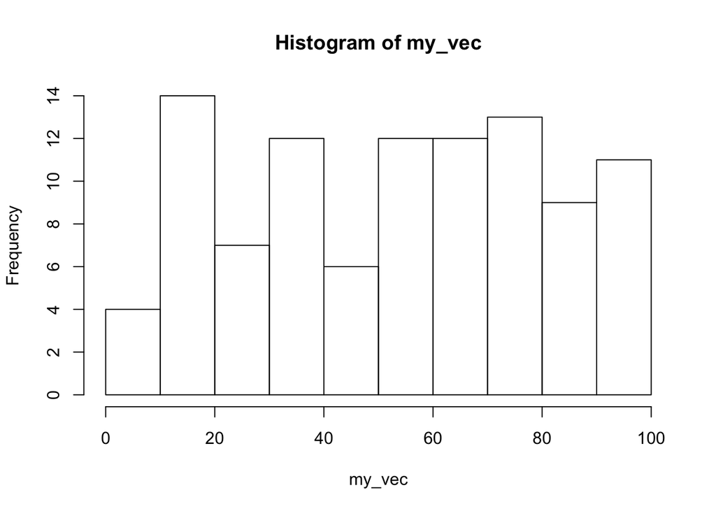

```r
hist(my_vec)
```

```r
??hist
```

## 1b. Answer:

### The hist() function produces a simple histogram of an object. The helpfile produces a deluge of information about the type of data to which the function can be applied as well as the arguments that are expected by the functon.

-1 Elaborate on what a histogram IS. It shows how frequently data appears, in bins

## 1c. Load up the mtcars data set using data(mtcars). Apply the following functions to mtcars: class, str, summary. What do these three functions tell you about mtcars?

```r
data(mtcars)
class(mtcars)
```

```
## [1] "data.frame"
```

```r
str(mtcars)
```

```
## 'data.frame':    32 obs. of  11 variables:
##  $ mpg : num  21 21 22.8 21.4 18.7 18.1 14.3 24.4 22.8 19.2 ...
##  $ cyl : num  6 6 4 6 8 6 8 4 4 6 ...
##  $ disp: num  160 160 108 258 360 ...
##  $ hp  : num  110 110 93 110 175 105 245 62 95 123 ...
##  $ drat: num  3.9 3.9 3.85 3.08 3.15 2.76 3.21 3.69 3.92 3.92 ...
##  $ wt  : num  2.62 2.88 2.32 3.21 3.44 ...
##  $ qsec: num  16.5 17 18.6 19.4 17 ...
##  $ vs  : num  0 0 1 1 0 1 0 1 1 1 ...
##  $ am  : num  1 1 1 0 0 0 0 0 0 0 ...
##  $ gear: num  4 4 4 3 3 3 3 4 4 4 ...
##  $ carb: num  4 4 1 1 2 1 4 2 2 4 ...
```

```r
summary(mtcars)
```

```
##       mpg             cyl             disp             hp
##  Min.   :10.40   Min.   :4.000   Min.   : 71.1   Min.   : 52.0
##  1st Qu.:15.43   1st Qu.:4.000   1st Qu.:120.8   1st Qu.: 96.5
##  Median :19.20   Median :6.000   Median :196.3   Median :123.0
##  Mean   :20.09   Mean   :6.188   Mean   :230.7   Mean   :146.7
##  3rd Qu.:22.80   3rd Qu.:8.000   3rd Qu.:326.0   3rd Qu.:180.0
##  Max.   :33.90   Max.   :8.000   Max.   :472.0   Max.   :335.0
##       drat             wt             qsec             vs
##  Min.   :2.760   Min.   :1.513   Min.   :14.50   Min.   :0.0000
##  1st Qu.:3.080   1st Qu.:2.581   1st Qu.:16.89   1st Qu.:0.0000
##  Median :3.695   Median :3.325   Median :17.71   Median :0.0000
##  Mean   :3.597   Mean   :3.217   Mean   :17.85   Mean   :0.4375
##  3rd Qu.:3.920   3rd Qu.:3.610   3rd Qu.:18.90   3rd Qu.:1.0000
##  Max.   :4.930   Max.   :5.424   Max.   :22.90   Max.   :1.0000
##        am              gear            carb
##  Min.   :0.0000   Min.   :3.000   Min.   :1.000
##  1st Qu.:0.0000   1st Qu.:3.000   1st Qu.:2.000
##  Median :0.0000   Median :4.000   Median :2.000
##  Mean   :0.4062   Mean   :3.688   Mean   :2.812
##  3rd Qu.:1.0000   3rd Qu.:4.000   3rd Qu.:4.000
##  Max.   :1.0000   Max.   :5.000   Max.   :8.000
```

## 1c. Answer:

### These functions describe the mtcars object as a data frame with 32 rows and 11 named columns of numeric data. The summary() function produces a five number summary for each column in the data frame that includes the minimum, mean, median, maximum, first quartile, and third quartile values.

## 1d. Look at the help file for the class data.frame. What does it tell you about these objects?

```r
??dplyr::data.frame
```

## 1d. Answer:

### These files are not as strongly typed as matrices or numerics. They can accept strings, floats, integers, and even multiple values as entries within a single data frame object. Data frames can also include multiple classes of data in a single object.

data.frames are both lists and matrices, and are fundamental to most of the modeling

# 2. Sample Properties

## 2a. Produce descriptive statistics for the following vasopressin expression levels in voles.

```r
vole_vaso <- c(98,96,94,88,86,82,77,74,70,60,
           59,52,50,47,40,35,29,13,6,5)
```

## 2b. What is the mean, median, sd, and interquartile range of the sample

```r
mean(vole_vaso)
```

```
## [1] 58.05
```

```r
median(vole_vaso)
```

```
## [1] 59.5
```

```r
sd(vole_vaso)
```

```
## [1] 29.75244
```

```r
IQR(vole_vaso)
```

```
## [1] 44.25
```

## 2c. What is the standard error of the mean (do this with a formula!)?

```r
vole_vaso
```

```
##  [1] 98 96 94 88 86 82 77 74 70 60 59 52 50 47 40 35 29 13  6  5
```

```r
std.er <- function(x){
  output <-sd(x)/sqrt(length(x))
  return(output)}
std.er(vole_vaso)
```

```
## [1] 6.652849
```

```r
sd(vole_vaso)
```

```
## [1] 29.75244
```

## 2d. What does the standard error of the mean tell you about our estimate of the mean values of the population of vole vassopressin?

## 2d. Answer:

### The standard error of the mean is a measurement of the precision of the estimate of the mean of a population for a particular sample size of that population.

good but the question also asks what the calculated SE tells you about this specific mean

# 3. Sample Size for upper quartiles.

## Let’s assume this sample of vole vassopressin expression is representative of the popultion.

## We can get the upper quartile value of vole vassopressin with

```r
quantile(vole_vaso, probs = 0.75)
```

```
## 75%
##  83
```

## 3a. Use sample() to get just one resample with a sample size of 10. What is its upper quartile?

```r
vole_vaso.resamped<-sample(x=vole_vaso,10, replace=T)
quantile(vole_vaso.resamped, probs=0.75)
```

```
##   75%
## 76.25
```

## 3b. Build an initial data frame for simulations with the sample sizes 5 through 20. Have 100 simulations per sample size.

```r
# initialize data frame description
for (i in 5:20){
   sampSim <- data.frame(samp_size=c(5:20),sim_num=list(100))}
str(sampSim)
```

```
## 'data.frame':    16 obs. of  2 variables:
##  $ samp_size: int  5 6 7 8 9 10 11 12 13 14 ...
##  $ X100     : num  100 100 100 100 100 100 100 100 100 100 ...
```

```r
# initialize data frame of appropriate size
for (i in 5:20){
   sampSim[[i]]<-map(i, ~data.frame(samp_size=rep(i,times=100)))}
str(sampSim)
```

[output not shown]

[output cut: 478 more lines]

[output not shown]

```r
x<-list()
for (i in 5:20){
   x[[i]]<-map(1:100, ~map(i, ~sample(vole_vaso, i,replace=T)))
   names(x[[i]])<-replicate(100, expr=paste0("samp_size",sep="",i))}
str(x)
```

[output not shown]

[output cut: 3150 more lines]

[output not shown]

### 3c. Use this data frame to get simulated upper quartiles for each sample size.

```r
for (i in 5:20){
   print(map(i, ~quantile(sample(vole_vaso, i,replace=T), probs=0.75)))}
```

```
## [[1]]
## 75%
##  59
##
## [[1]]
##  75%
## 68.5
##
## [[1]]
## 75%
##  91
##
## [[1]]
##  75%
## 83.5
##
## [[1]]
## 75%
##  88
##
## [[1]]
## 75%
##  73
##
## [[1]]
## 75%
##  85
##
## [[1]]
## 75%
##  83
##
## [[1]]
## 75%
##  74
##
## [[1]]
##  75%
## 92.5
##
```

[output cut: 8 more lines]

```
## [[1]]
## 75%
##  82
##
## [[1]]
##   75%
## 75.25
##
## [[1]]
## 75%
##  84
##
## [[1]]
##   75%
## 78.25
```

### 3d. With a plot, make a guesstimate as to the best sample size for estimating the upper quartile of the population.

```r
for (i in 5:20){
   print(map(i, ~std.er(sample(vole_vaso, i,replace=T))))}
```

```
## [[1]]
## [1] 11.75755
##
## [[1]]
## [1] 14.15254
##
## [[1]]
## [1] 10.03904
##
## [[1]]
## [1] 9.862899
##
## [[1]]
## [1] 7.619622
##
## [[1]]
## [1] 9.308061
##
## [[1]]
## [1] 8.219509
##
## [[1]]
## [1] 9.790579
##
## [[1]]
## [1] 8.345238
##
## [[1]]
## [1] 7.834658
##
## [[1]]
## [1] 5.105739
##
## [[1]]
## [1] 6.421623
##
## [[1]]
## [1] 6.697718
##
## [[1]]
## [1] 7.485158
##
## [[1]]
## [1] 5.986005
##
## [[1]]
## [1] 6.140675
```

```r
for (i in 5:20){
   qnts<-map(i, ~quantile(sample(vole_vaso, i,replace=T), probs=0.75))
   qnts.df<-data.frame(qnts)
   qnts.df
   print(qnts.df)
   std.er(qnts.df)
   sd(qnts.df)}
```

```
##     structure.88...Names....75...
## 75%                            88
##     structure.85...Names....75...
## 75%                            85
##     structure.73.5...Names....75...
## 75%                            73.5
##     structure.81.25...Names....75...
## 75%                            81.25
##     structure.88...Names....75...
## 75%                            88
##     structure.72.75...Names....75...
## 75%                            72.75
##     structure.86...Names....75...
## 75%                            86
##     structure.63.5...Names....75...
## 75%                            63.5
##     structure.82...Names....75...
## 75%                            82
##     structure.74...Names....75...
## 75%                            74
##     structure.81.5...Names....75...
## 75%                            81.5
##     structure.94.5...Names....75...
## 75%                            94.5
##     structure.82...Names....75...
## 75%                            82
##     structure.67.5...Names....75...
## 75%                            67.5
##     structure.81.5...Names....75...
## 75%                            81.5
##     structure.85...Names....75...
## 75%                            85
```

```r
str(qnts.df)
```

```
## 'data.frame':    1 obs. of  1 variable:
##  $ structure.85...Names....75...: num 85
```

-2 Where is your plot?

# 4. SE and CI

## 4a. With the upper quartile simulations, calculate the SD for each sample size using dplyr

## 4b. What does this value, the standard error of the upper quartile, mean?

## 4c. What is the CI of the upper quartile with a sample size of 10. What does this mean?

[output not shown]

[output not shown]

[output cut: 4943 more lines]

[output not shown]

[output not shown]

[output cut: 26921 more lines]

[output not shown]

-3 Instructions say to use dplyr, not for() loops

vole_sim_summarize <- vole_sim %>% group_by(samp_size) %>% summarize(uq_se = sd(uq)) %>% ungroup()

## 4d. Extra Credit: Instead of having each sim calculate a upper quartile, and then sifting down to the SE of that upper quartile (or the CI), have each simulation calculate a CI. Then, for just a sample size of 10, how many CI’s contain the true value of 83?